# 2023 Credit Card Expense data

# Ok...

I guess I spent the most on restaurants, groceries, and clothes. Interesting. Some subcategories are still inaccurate though (as you can see below) so I'm gonna categorize by looking at the csv and using brute force.

```python
data.head()
```

|  | Subcategory | Date | Location | Payee | Description | Amount |
| --- | --- | --- | --- | --- | --- | --- |
| 0 | Gasoline | 12/05/2023 | BRENTWOOD ,CA | 7-ELEVEN | 7-ELEVEN 38723 BRENTWOOD ,CA | 30 |
| 1 | Gasoline | 08/14/2023 | Washington ,DC | DUPONT CIRCLE FARMERS | SQ *DUPONT CIRCLE FARMERS Washington ,DC | 3 |
| 2 | Gasoline | 08/14/2023 | WASHINGTON ,DC | FOXTROT MARKET | FOXTROT MARKET-MT VERNON WASHINGTON ,DC | 5 |
| 3 | Gasoline | 08/12/2023 | WASHINGTON ,DC | FOXTROT MARKET | FOXTROT MARKET - DUPONT WASHINGTON ,DC | 13 |
| 4 | Gasoline | 08/06/2023 | Brooklyn ,NY | WILLIAMS FRUIT FARM | SQ *WILLIAMS FRUIT FARM Brooklyn ,NY | 7 |

### Categorizing correctly

```python
def subcategory(category, purchase):
    if any(keyword in purchase for keyword in ["WILLOW", "COFFEE"]):
        return "Coffee Shops" #it categorized a tea spot as a bars/alcohol.
    if any(keyword in purchase for keyword in ["FOOD COLLECTIVE", "FOXTROT ", "FRUIT FARM", "PRETA", "FARMERS",
                                              "QUAKER VALLEY FOODS", "TOKYO FISH"]):
        return "Groceries"
    if "BART" in purchase:
        return "Public Transportation"
    if "GOLF CLUB" in purchase:
        return "Recreation/Fitness/Clubs"
    if "GODADDY" in purchase:
        return "Domain"
    if "BERKELEY PARK" in purchase:
        return "Fine"
    if "EVERLANE" in purchase:
        return "Clothing/Accessories"
    if "SOUTH BLOCK" in purchase:
        return "Other Food/Drink"
    return category
```

```python
def fix_categories(subcategory):
    if "Fast Food" in subcategory:
        return "Coffee Shops" # it categorized all my coffee places as fast food
    return subcategory
```

```python
data['Subcategory'] = data.apply(lambda row: subcategory(row['Subcategory'], row['Payee']), axis=1)
data['Subcategory'] = data['Subcategory'].apply(fix_categories)
```

```python
#IT WORKED!

data
```

|  | Subcategory | Date | Location | Payee | Description | Amount |
| --- | --- | --- | --- | --- | --- | --- |
| 0 | Gasoline | 12/05/2023 | BRENTWOOD ,CA | 7-ELEVEN | 7-ELEVEN 38723 BRENTWOOD ,CA | 30 |
| 1 | Groceries | 08/14/2023 | Washington ,DC | DUPONT CIRCLE FARMERS | SQ *DUPONT CIRCLE FARMERS Washington ,DC | 3 |
| 2 | Groceries | 08/14/2023 | WASHINGTON ,DC | FOXTROT MARKET | FOXTROT MARKET-MT VERNON WASHINGTON ,DC | 5 |
| 3 | Groceries | 08/12/2023 | WASHINGTON ,DC | FOXTROT MARKET | FOXTROT MARKET - DUPONT WASHINGTON ,DC | 13 |
| 4 | Groceries | 08/06/2023 | Brooklyn ,NY | WILLIAMS FRUIT FARM | SQ *WILLIAMS FRUIT FARM Brooklyn ,NY | 7 |
| ... | ... | ... | ... | ... | ... | ... |
| 545 | Other Food/Drink | 07/17/2023 | Washington ,DC | SOUTH BLOCK | SQ *SOUTH BLOCK - LOGAN C Washington ,DC | 21 |
| 546 | Other Food/Drink | 07/16/2023 | Washington ,DC | SOUTH BLOCK | SQ *SOUTH BLOCK - LOGAN C Washington ,DC | 9 |
| 547 | Other Food/Drink | 07/04/2023 | Washington ,DC | SOUTH BLOCK | SQ *SOUTH BLOCK - LOGAN C Washington ,DC | 9 |
| 548 | Other Food/Drink | 07/01/2023 | Washington ,DC | SOUTH BLOCK | SQ *SOUTH BLOCK - UNION M Washington ,DC | 9 |
| 549 | Other Food/Drink | 06/25/2023 | Washington ,DC | SOUTH BLOCK | SQ *SOUTH BLOCK - LOGAN C Washington ,DC | 9 |

550 rows × 6 columns

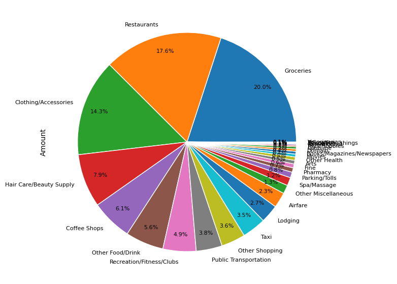

```python
categories_fixed = data['Amount'].groupby(data['Subcategory']).sum().reset_index().sort_values(by='Amount', ascending = False)
to_plot2 = categories_fixed[["Amount"]]
to_plot2.index = categories_fixed['Subcategory']
plot2 = to_plot2.plot.pie(y='Amount', figsize=(7, 7), autopct='%1.1f%%', wedgeprops={
    'linewidth': 1, 'edgecolor': 'white'}, fontsize=8, pctdistance=0.85)

plot2.get_legend().remove()
```

# Let's compare WF's categories with mine

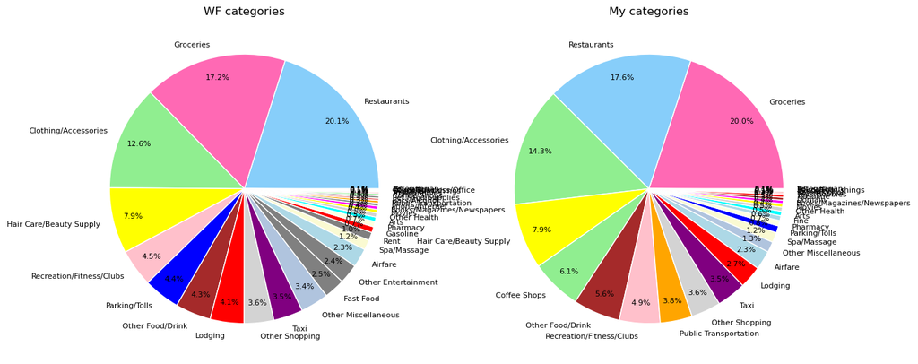

```python
num_categories = len(data['Subcategory'].unique())
cmap = plt.get_cmap('tab20')

fig, axs = plt.subplots(1, 2, figsize=(14, 7))

specific_colors = {
    'Gasoline': 'red',
    'Groceries': 'hotpink',
    'Parking/Tolls': 'blue',
    'Public Transportation': 'orange',
    'Taxi': 'purple',
    'Domain': 'brown',
    'Recreation/Fitness/Clubs': 'pink',
    'Arts': 'cyan',
    'Books/Magazines/Newspapers': 'magenta',
    'Movies': 'yellow',
    'Fine': 'lightblue',
    'Coffee Shops': 'lightgreen',
    'Bars/Alcohol': 'lightcoral',
    'Restaurants': 'lightskyblue',
    'Other Food/Drink': 'brown',
    'Eyecare': 'lightpink',
    'Pharmacy': 'lightyellow',
    'Other Health': 'lightgrey',
    'Décor/Furnishings': 'lavender',
    'Education': 'lightseagreen',
    'Other Miscellaneous': 'lightsteelblue',
    'Clothing/Accessories': 'lightgreen',
    'Hair Care/Beauty Supply': 'yellow',
    'Spa/Massage': 'lightgoldenrodyellow',
    'Veterinarian': 'lightgrey',
    'Toys/Hobbies': 'lightpink',
    'Other Shopping': 'lightgrey',
    'Airfare': 'lightblue',
    'Lodging': 'red'
}

to_plot.plot.pie(ax=axs[0], y='Amount', autopct='%1.1f%%', wedgeprops={
    'linewidth': 1, 'edgecolor': 'white'}, fontsize=8, pctdistance=0.85, colors=[specific_colors.get(label, 'grey') for label in to_plot.index]).get_legend().remove()

axs[0].set_title('WF categories')
axs[0].set_ylabel('')

to_plot2.plot.pie(ax=axs[1], y='Amount', autopct='%1.1f%%', wedgeprops={
    'linewidth': 1, 'edgecolor': 'white'}, fontsize=8, pctdistance=0.85, colors=[specific_colors.get(label, 'grey') for label in to_plot2.index]).get_legend().remove()

axs[1].set_title('My categories')
axs[1].set_ylabel('')
```

Ok this isn't a great visual. The differences aren't easy to see. Let's try a bar chart.

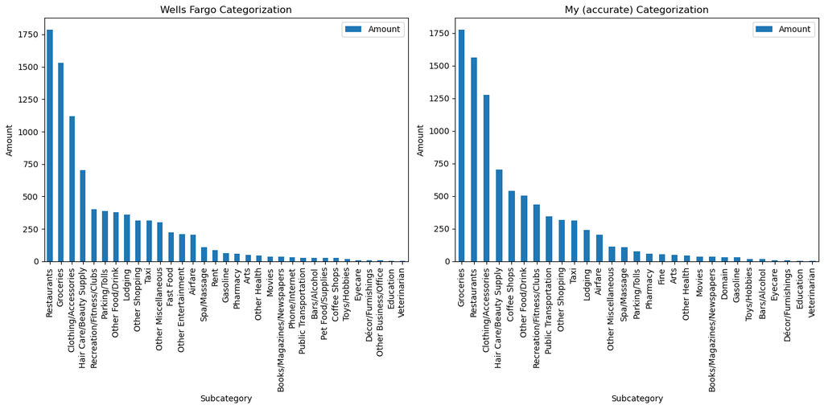

```python
fig, axs = plt.subplots(1, 2, figsize=(14, 7))

# Plot the first bar chart on the left subplot
to_plot.plot.bar(ax=axs[0])
axs[0].set_title('Wells Fargo Categorization')
axs[0].set_ylabel('Amount')

# Plot the second bar chart on the right subplot
to_plot2.plot.bar(ax=axs[1])
axs[1].set_title('My (accurate) Categorization')
axs[1].set_ylabel('Amount')

# Show the plots
plt.tight_layout()
plt.show()
```

I suppose the most significant difference is how much I spent on coffee. WF thinks I barely went to coffee shops, but when I fixed the categories you can see I spent close to 500 bucks on coffee last year. Don't know how to feel about this.

## Top ten things I spent money on

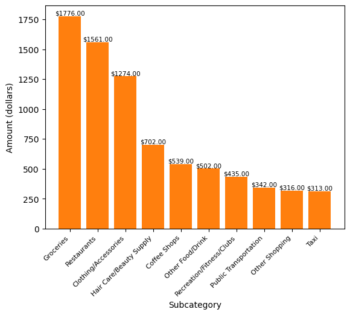

```python
top_ten = categories_fixed.head(10)
plt.bar(top_ten['Subcategory'], top_ten['Amount'])
plt.xlabel('Subcategory')
plt.ylabel('Amount (dollars)')
plt.xticks(fontsize=8, rotation=45, ha='right')
bars1 = plt.bar(top_ten['Subcategory'], top_ten['Amount'])
for bar in bars1:
    yval = bar.get_height()
    plt.text(bar.get_x() + bar.get_width()/2, yval, '${:.2f}'.format(yval), va='bottom', ha='center', fontsize=7.5)
```

## What city/state/country did I spend the most money?

```python
location = data['Amount'].groupby(data['Location']).sum().reset_index()
location.head()
```

|  | Location | Amount |
| --- | --- | --- |
| 0 | 120-36845156 ,CA | 60 |
| 1 | 124-08994737 ,DC | 62 |
| 2 | 151-05901648 ,CA | 11 |
| 3 | 151-85480316 ,NY | 223 |
| 4 | 161-79554467 ,NY | 17 |

Let's fix the locations since many are repeated. Gotta use brute force but if only there was some AI that could do this! I'm sure there is I just don't know what it is or how to use it yet.

```python
def fix_location(location):
    if  any(keyword in location for keyword in ["DC", "GA", "WA"]):
        return "DC"
    if any(keyword in location for keyword in ["New York", "NEW YORK", "NY"]):
        return "New York"
    if "Berkeley" in location:
        return "Berkeley"
    if ",CA" in location:
        return "California"
    if "MD" in location:
        return "Maryland"
    if "VA" in location:
        return "Virginia"
    if "AZ" in location:
        return "Delhi" #(edge case)
    if "CD" in location:
        return "Canada"
    if "PA" in location:
        return "Pennsylvania"
    if "NJ" in location:
        return "New Jersey"
    return loc
```

```python
fixed_locations = []
for loc in np.array(location["Location"]):
    fixed_locations.append(fix_location(loc))
```

```python
location['Location'] = fixed_locations
location = location['Amount'].groupby(location['Location']).sum().reset_index()
location = location.sort_values(by='Amount', ascending=False)
location
```

|  | Location | Amount |
| --- | --- | --- |
| 1 | California | 4677 |
| 3 | DC | 2402 |
| 7 | New York | 935 |
| 0 | Berkeley | 724 |
| 8 | Pennsylvania | 41 |
| 6 | New Jersey | 36 |
| 4 | Delhi | 31 |
| 5 | Maryland | 20 |
| 9 | Virginia | 20 |
| 2 | Canada | 6 |

```python
pie = location[["Amount"]]
pie.index = location['Location']
```

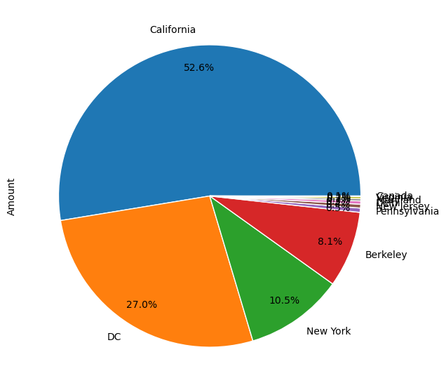

```python
plot = pie.plot.pie(y='Amount', figsize=(7, 7), autopct='%1.1f%%', wedgeprops={
    'linewidth': 1, 'edgecolor': 'white'}, fontsize=10, pctdistance=0.85)
plot.get_legend().remove()
```

I'm growing cold towards pie charts now.

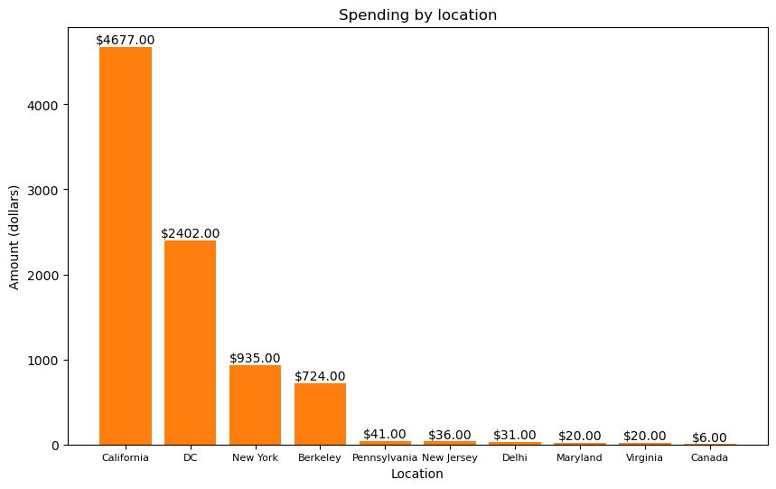

```python
plt.figure(figsize=(10, 6))
plt.bar(location['Location'], location['Amount'])
plt.xticks(fontsize=8)
plt.xlabel('Location')
plt.ylabel('Amount (dollars)')
plt.title('Spending by location')
bars = plt.bar(location['Location'], location['Amount'])
for bar in bars:
    yval = bar.get_height()
    plt.text(bar.get_x() + bar.get_width()/2, yval, '${:.2f}'.format(yval), va='bottom', ha='center')
```

Alrighty, very cool.

## Summary

I spent a **total of 8892 dollars** on my credit card in 2023. That's **743460.12 rupees** (as of the 4/12 83.61 converstion rate) cause the other half of my brain works in rupees. **I went completely ham in July.** I spent the most money on **food** (unsurprising), **clothes**, **hair care/beauty supply** (which includes waxes and threading so I would just rename this to **salons**), and **coffee shops**. Spent the most in California, followed by DC, NYC, and Berkeley (which isn't included in the California category).

My spending habits were pretty whack last year. But I had fun! Was living in a studio in a new city with my own income for the first time so went a little crazy, but I don't have regrets. I look back at most of this with fondness. :)